# ACP joueurs de rugby : projet 2025-2026 franck

AHOUANGASSI FRANCK

# 1) Chargement des données

```r
RUGBY = read.csv("http://www.math.univ-toulouse.fr/~ferraty/DATA/rugby.csv", row.names = 1, stringsAsFactors=TRUE)
```

# 2) Affichage du résumé des données

```r
summary(RUGBY)
```

```
##        position     pack        taille          poids       club_match
##  2eme_ligne:6   pack_N:17   Min.   :1.710   Min.   : 76   Min.   : 0.000
##  ouverture :6   pack_O:12   1st Qu.:1.780   1st Qu.: 87   1st Qu.: 1.000
##  3eme_ligne:3               Median :1.880   Median : 97   Median :10.000
##  centre    :3               Mean   :1.867   Mean   :102   Mean   : 8.724
##  relanceur :3               3rd Qu.:1.930   3rd Qu.:115   3rd Qu.:14.000
##  demi      :2               Max.   :2.070   Max.   :151   Max.   :22.000
##  (Other)   :6
##      club_V        club_points      other_match       other_V
##  Min.   : 0.000   Min.   :  0.00   Min.   :0.000   Min.   :0.00
##  1st Qu.: 0.000   1st Qu.:  0.00   1st Qu.:0.000   1st Qu.:0.00
##  Median : 6.000   Median :  5.00   Median :4.000   Median :2.00
##  Mean   : 5.655   Mean   : 41.07   Mean   :3.517   Mean   :2.69
##  3rd Qu.:10.000   3rd Qu.: 88.00   3rd Qu.:7.000   3rd Qu.:5.00
##  Max.   :13.000   Max.   :177.00   Max.   :8.000   Max.   :8.00
##
##   other_points
##  Min.   : 0.00
##  1st Qu.: 0.00
##  Median : 5.00
##  Mean   :15.48
##  3rd Qu.:25.00
##  Max.   :85.00
##
```

Notre jeux de donnée nous fournie un totale de 29 individus et 10 variables ,8 variables quantitative et 2 variables qualitatives qui seront considérées comme variables supplémentaires dans notre analyses

# 3) Réalisation de l’ACP SANS représentation des individus et variables

```r
library(FactoMineR)
```

```r
RUGBY.pca=PCA(RUGBY,quali.sup = 1:2,graph = FALSE)
```

# 4) Décroissance des inerties : combien d’axes doit-on retenir pour réaliser l’ACP?

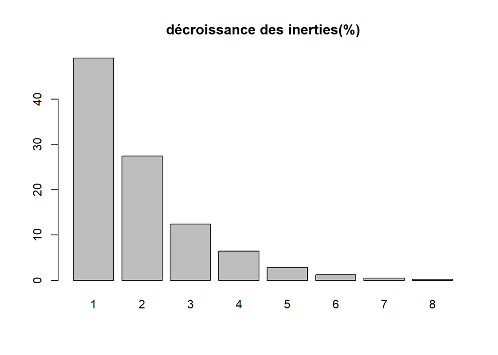

```r
barplot(RUGBY.pca$eig[,2],main="décroissance des inerties(%)",names.arg = 1:nrow(RUGBY.pca$eig))
```

On va considérer les 2 premiers axes car ils représentent 76% de l’inerties totale;plus de 76% de l’inertie est liée au plan principale ce qui propose une représentation globlale suffisamment fidèle des données

**NB**:Il pourrait être intérréssant de pousser l’analyse jusqu’a la troisième dimension pour avoir une confirmation par rapport au sens des données

# 5) Représentation des individus

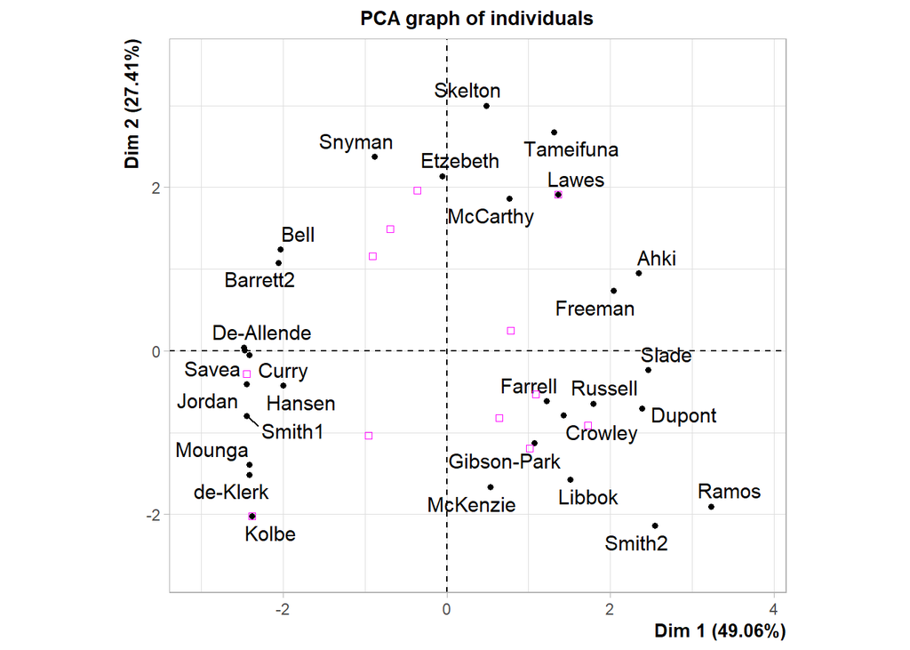

```r
plot.PCA(RUGBY.pca,choix="ind",label = "ind")
```

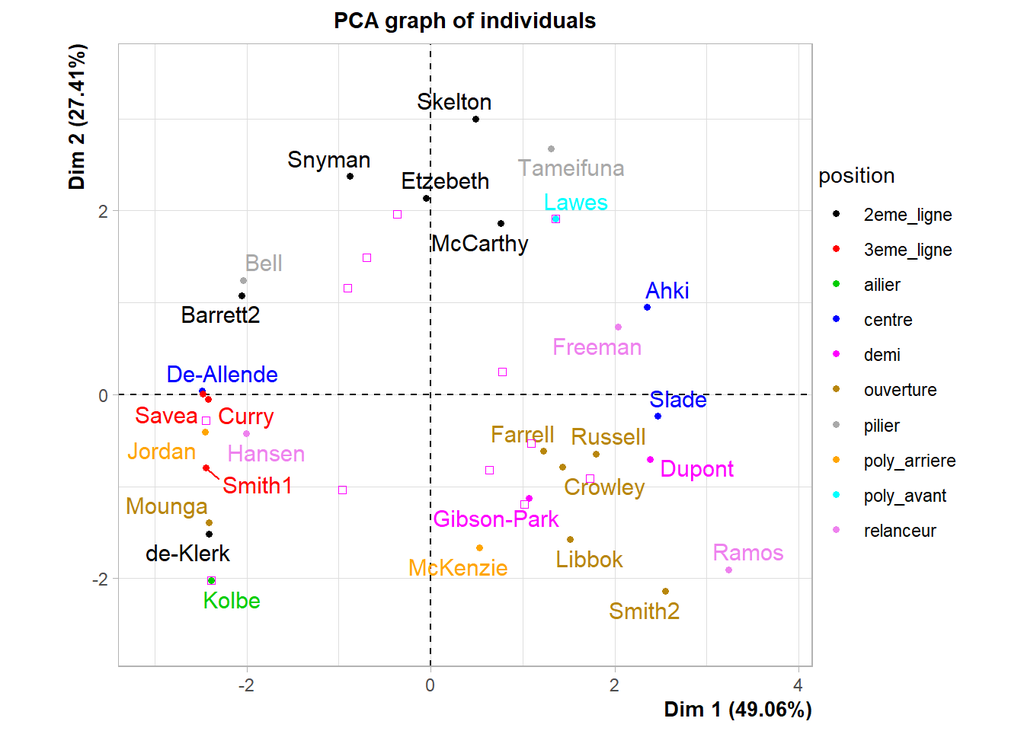

```r
plot.PCA(RUGBY.pca,choix="ind",habillage = "position",label = "ind")
```

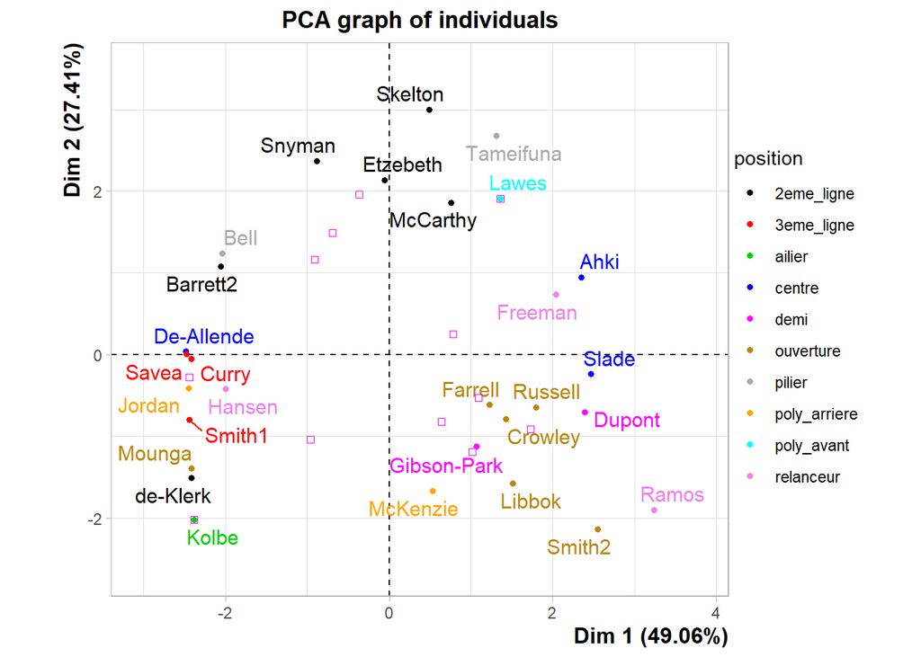

```r
plot.PCA(RUGBY.pca,choix="ind",habillage = "position",label = "ind",cex.main=1.2,cex.axis=1.2)
```

# 6) Représentation des variables

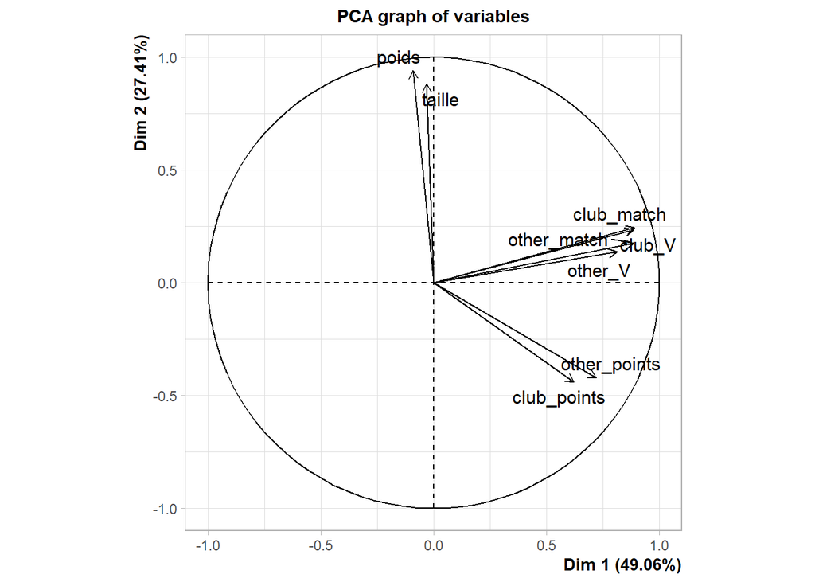

```r
plot.PCA(RUGBY.pca,choix="var",label = "var")
```

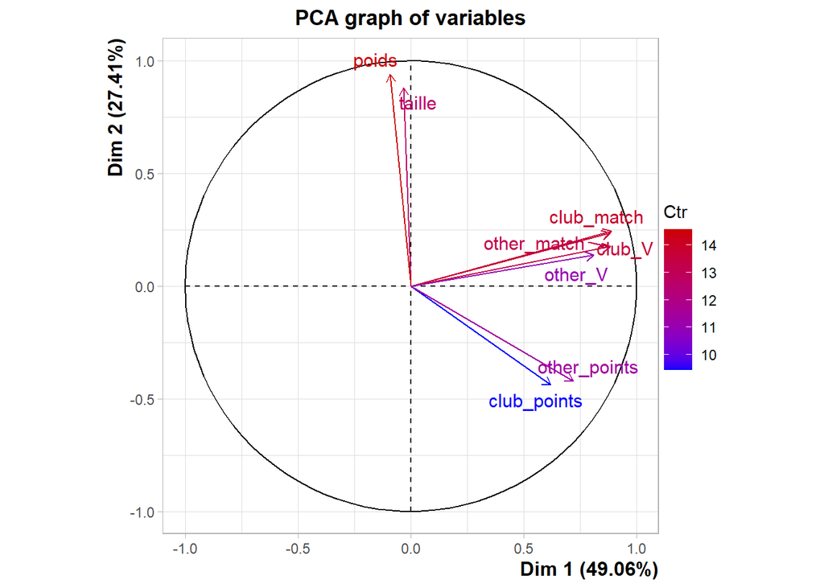

```r
plot.PCA(RUGBY.pca,choix="var",habillage = "contrib",label = "var",cex.main=1.2,cex.axis=1.2)
```

# 7) Interprétation de l’axe 1

## Identification des variables corrélées avec l’axe 1

Les variables fortement corrélé avec l’axe 1 sont **club_match**,**club_V**,**other_match**,**other_V**,**other_points**,**club_points** .ces variables prennent toutes des valeurs positives (respectivement:*0.889,0.884,0.884,0.811,0.721,0.620*) par opposition avec les variables les faiblement corrélé qui prennent des valeurs négatives **taille**,**poids**(respectivement:*-0.031,-0.092*) les sorties numériques sont visibles dans le premier tableau en annex (colonne “Dim.1”)

##Positionnement des individus en fonction des corrélations entre variables et axe 1

les individus les plus à droite vont prendre des valeurs élevés pour les variables **club_match**,**club_V**,**other_match**,**other_V**,**other_points**,**club_points** se plus à gauche(dans l’autre moitié du plan) vont prendrent des valeurs négatives pour les mêmes variables

# 8) Interprétation de l’axe 2

## Identification des variables corrélées avec l’axe 2

Les variables ayant une forte corrélation avec l’axe 2 sont les variables **taille**,**poids** qui prennent des valeurs fortement positive . les variables *club_match,club_v,other_v* prennent des valeurs positives faibles

on a basé notre lecture sur les corrélations se trouvant dans les sorties numériques (colonne “Dim.2”)

## Positionnement des individus en fonction des corrélations entre variables et axe 2

Les individus les plus hauts prennent de forte valeurs pour les variables **taille**,**poids** inversement les individus les plus bas prennent valeur faible pour ces variables . L’observation montre aussi que les individus se trouvant plus haut ont des valeurs assez faible par rapport au variables **other_points**,**club_points** et les individus plus bas prennent des valeurs assez forte

# 9) Synthèse

## Contextualisation des interprétations

Les joueurs de rugby se positionnant à droite ont joué un grand nombre de match avec l’équipe du club ,ont marqué un grand nombre de points avec l’équipe du club,ont un grand nombre de victoire avec l’équipe du club;ils ont aussi de nombreux match jouer en dehors de l’équipe du club où ils ont accumulé un grand nombre de victoires et ont marqué beaucoup de points

Contrairement aux joueurs à droite, les joueurs à gauche n’ont pas joué un grand nombre de match avec l’équipe du club ,n’ont pas marqué un grand nombre de points avec l’équipe du club,n’ont pas un grand nombre de victoire avec l’équipe du club;ils ont aussi de peu de nombre de match jouer en dehors de l’équipe du club où ils n’ont accumulé que peu de victoires et n’ont marqué que peu de points

Les joueurs se trouvant le plus en haut dans le plan ont une grande taille et poids important

Les joueurs en bas du plan ont une petite taille et un faible poids

##Interprétation des groupes

les joueurs de **3eme_ligne** n’ont pas joué un grand nombre de match avec l’équipe du club ,n’ont pas marqué un grand nombre de points avec l’équipe du club,n’ont pas un grand nombre de victoire avec l’équipe du club;ils ont aussi de peu de nombre de match jouer en dehors de l’équipe du club où ils n’ont accumulé que peu de victoires et n’ont marqué que peu de points.Ils est aussi intéréssant de constater que ces joueurs ont aussi une taille et un poids assez faible

Les joueurs de 2eme_ligne ont en moyenne une taille et un poids assez élevé(à l’exception **de-Klerk**)

Des joueurs tel que **Tameifuna** et **Kolbe** sont des joueurs avec des caractéristiques opposé Tameifuna(position:pilier) possède un poids et une taille importante et fait partie des meilleurs joueurs par opposition à Kolbe(position:ailier) qui à une taille et un poids faible et ne fait pas partie des meilleurs joueurs

# Annexes

```r
library(kableExtra)
summary(RUGBY.pca)
```

```
##
## Call:
## PCA(X = RUGBY, quali.sup = 1:2, graph = FALSE)
##
##
## Eigenvalues
##                        Dim.1   Dim.2   Dim.3   Dim.4   Dim.5   Dim.6   Dim.7
## Variance               3.925   2.193   0.993   0.511   0.230   0.094   0.039
## % of var.             49.061  27.410  12.414   6.393   2.870   1.177   0.490
## Cumulative % of var.  49.061  76.471  88.885  95.278  98.148  99.325  99.815
##                        Dim.8
## Variance               0.015
## % of var.              0.185
## Cumulative % of var. 100.000
##
## Individuals (the 10 first)
##                  Dist    Dim.1    ctr   cos2    Dim.2    ctr   cos2    Dim.3
## Gibson-Park  |  2.723 |  1.068  1.003  0.154 | -1.125  1.990  0.171 | -2.182
## Farrell      |  1.788 |  1.223  1.315  0.468 | -0.615  0.594  0.118 |  0.927
## Freeman      |  2.383 |  2.037  3.645  0.730 |  0.733  0.844  0.095 | -0.535
## McCarthy     |  2.622 |  0.761  0.509  0.084 |  1.862  5.450  0.504 | -1.474
## Crowley      |  2.140 |  1.431  1.800  0.447 | -0.789  0.980  0.136 |  1.207
## Barrett2     |  2.455 | -2.058  3.720  0.702 |  1.079  1.832  0.193 |  0.464
## Etzebeth     |  2.498 | -0.053  0.002  0.000 |  2.136  7.176  0.731 | -0.830
## Hansen       |  2.151 | -2.000  3.515  0.865 | -0.423  0.281  0.039 | -0.131
## Bell         |  2.563 | -2.035  3.639  0.630 |  1.241  2.422  0.234 |  0.461
## Russell      |  2.658 |  1.793  2.824  0.455 | -0.643  0.651  0.059 |  1.410
##                 ctr   cos2
## Gibson-Park  16.526  0.642 |
## Farrell       2.987  0.269 |
## Freeman       0.996  0.050 |
## McCarthy      7.545  0.316 |
## Crowley       5.061  0.318 |
## Barrett2      0.748  0.036 |
## Etzebeth      2.393  0.110 |
## Hansen        0.060  0.004 |
## Bell          0.739  0.032 |
## Russell       6.903  0.281 |
##
## Variables
```

[output cut: 27 more lines]

```
## pilier       |  2.418 | -0.363  0.023 -0.264 |  1.959  0.657  1.906 |  0.601
## poly_arriere |  1.978 | -0.959  0.235 -0.697 | -1.038  0.275 -1.009 |  1.205
## poly_avant   |  2.532 |  1.360  0.288  0.686 |  1.910  0.569  1.290 | -0.672
## relanceur    |  1.270 |  1.091  0.737  0.990 | -0.531  0.175 -0.644 | -0.269
##                cos2 v.test
## 2eme_ligne    0.003 -0.251 |
## 3eme_ligne    0.003 -0.260 |
## ailier        0.029 -0.556 |
## centre        0.000 -0.025 |
## demi          0.426 -2.632 |
## ouverture     0.095  1.397 |
## pilier        0.062  0.869 |
## poly_arriere  0.371  1.741 |
## poly_avant    0.070 -0.675 |
## relanceur     0.045 -0.485 |
```

```r
dimdesc(RUGBY.pca)
```

```
## $Dim.1
##
## Link between the variable and the continuous variables (R-square)
## =================================================================================
##              correlation      p.value
## club_match     0.8894590 1.115212e-10
## other_match    0.8837382 2.128048e-10
## club_V         0.8835540 2.171575e-10
## other_V        0.8112701 9.380274e-08
## other_points   0.7208334 1.030596e-05
## club_points    0.6204550 3.297977e-04
##
## Link between the variable and the categorical variable (1-way anova)
## =============================================
##             R2    p.value
## pack 0.1472682 0.03986719
##
## Link between variable and the categories of the categorical variables
## ================================================================
##                      Estimate    p.value
## pack=pack_N          0.771826 0.03986719
## pack=pack_O         -0.771826 0.03986719
## position=3eme_ligne -2.357987 0.02360523
##
## $Dim.2
##
## Link between the variable and the continuous variables (R-square)
## =================================================================================
##              correlation      p.value
## poids          0.9400469 3.917938e-14
## taille         0.8802559 3.102656e-10
## other_points  -0.4212717 2.285073e-02
## club_points   -0.4393997 1.708392e-02
##
## Link between the variable and the categorical variable (1-way anova)
## =============================================
##                 R2     p.value
## pack     0.4332707 0.000103888
## position 0.6659839 0.004041005
##
## Link between variable and the categories of the categorical variables
## ================================================================
##                       Estimate     p.value
## pack=pack_O          0.9895385 0.000103888
## position=2eme_ligne  1.5259415 0.004373712
## position=ouverture  -1.1559610 0.026609966
## pack=pack_N         -0.9895385 0.000103888
##
## $Dim.3
##
## Link between the variable and the continuous variables (R-square)
## =================================================================================
##             correlation      p.value
## club_points   0.5942592 0.0006759742
## other_match  -0.4013317 0.0309422614
## other_V      -0.5377327 0.0026255419
##
## Link between variable and the categories of the categorical variables
## ================================================================
##                Estimate     p.value
## position=demi -1.697005 0.006036334
```

```r
sort(RUGBY.pca$var$cos2["club_points", ])
```

```
##      Dim.4      Dim.5      Dim.2      Dim.3      Dim.1
## 0.01713977 0.02154333 0.19307212 0.35314398 0.38496436
```

```r
kable(RUGBY.pca$eig[1,])
```

|  | x |
| --- | --- |
| eigenvalue | 3.924858 |
| percentage of variance | 49.060722 |
| cumulative percentage of variance | 49.060722 |